# Chapter 3 analysis

In this analysis a data chart of student alcohol consumption in Portugal is used in examination of it’s previously counted variable high use. In this chapter I’ll choose 4 interesting variables and present a hypothesis on how they correlate with high/low alchohol consupmtion. The variables I choose are failure, study time, health and absences from school. Here are the hypothesis I will study through this chapter:

H1: High alcohol consumption affects amount of course failures. H2: More time spent on studying implys less alcohol consupmtion H3: Higher health indicates less alcohol consumption. H4: High amount of absences are related to high alcohol consumption.

Let’s look at the variables individually. These variables are now extraced to their own table, so we can look them with glimpse- function.

```
## Observations: 382
## Variables: 5
## $ high_use  <lgl> FALSE, FALSE, TRUE, FALSE, FALSE, FALSE, FALSE, FALS...
## $ failures  <int> 0, 0, 2, 0, 0, 0, 0, 0, 0, 0, 0, 0, 0, 0, 0, 0, 0, 0...
## $ studytime <int> 2, 2, 2, 3, 2, 2, 2, 2, 2, 2, 2, 3, 1, 2, 3, 1, 3, 2...
## $ health    <int> 3, 3, 3, 5, 5, 5, 3, 1, 1, 5, 2, 4, 5, 3, 3, 2, 2, 4...
## $ absences  <int> 5, 3, 8, 1, 2, 8, 0, 4, 0, 0, 1, 2, 1, 1, 0, 5, 8, 3...
```

```
## Observations: 1,910
## Variables: 2
## $ key   <chr> "high_use", "high_use", "high_use", "high_use", "high_us...
## $ value <int> 0, 0, 1, 0, 0, 0, 0, 0, 0, 0, 0, 0, 0, 0, 0, 0, 0, 0, 1,...
```

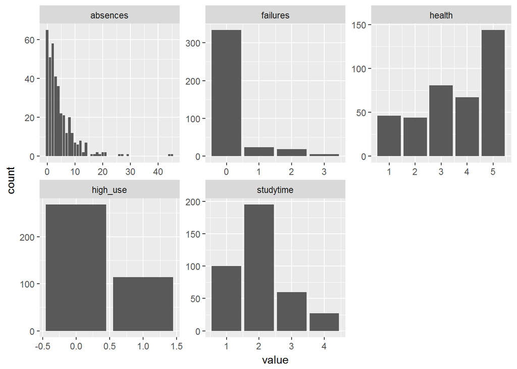

There can be no further conclusions divided from this set of data, so let’s dig deeper.

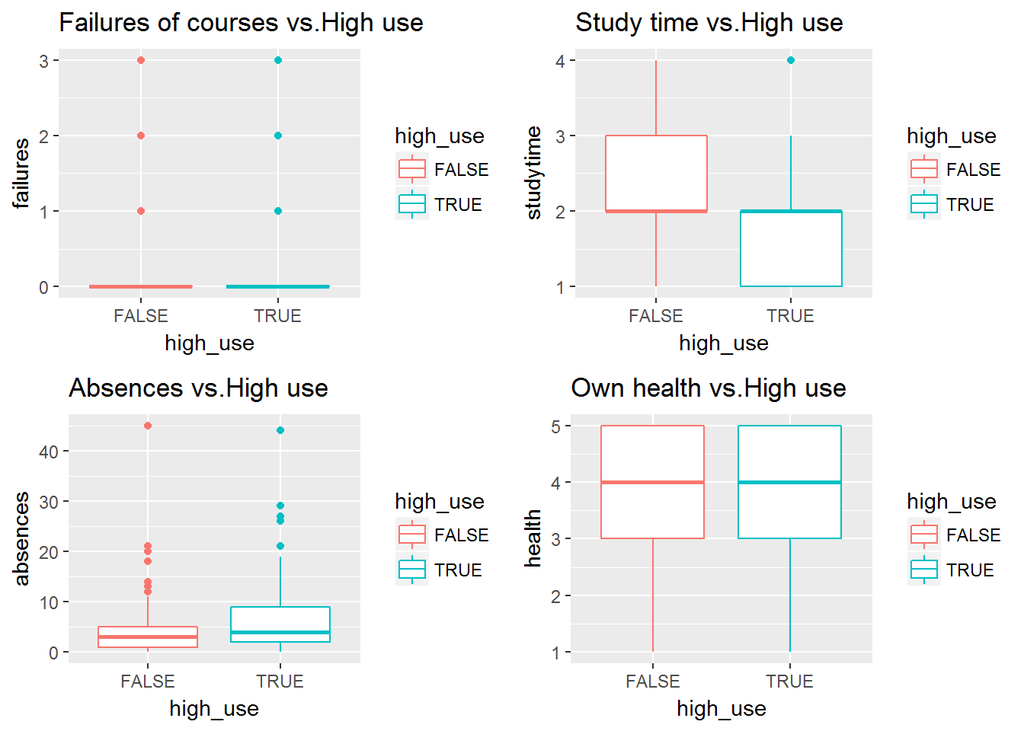

Here we can see that one from our models is not good (atleast as boxplot). Failures show only two lines and is therefore hard to make conclusion on one way or another.

On the other hand, health, study time and absence are vieweable and show some concluding evidence. People who are not high users answered that they spend more time studying than high users. Also, people who are high users have more absences compared to non-high users. What is suprising here is that both high users and non- high users have the same values of answers in health, meaning regardless of alcohol usage level they feel enough healthy.

Let’s still keep the values here to see if the chosen plot type had effect on the results. Next, I will make a model using logistic regression. This type of analysis style is good, if variables have a fair amount of two- digit variablse (only values true/false or yes/no eg.).

```
##
## Call:
## glm(formula = high_use ~ failures + health + absences + studytime,
##     family = "binomial", data = alc_hyp)
##
## Deviance Residuals:
##     Min       1Q   Median       3Q      Max
## -2.1963  -0.8269  -0.6563   1.1481   2.1371
##
## Coefficients:
##             Estimate Std. Error z value Pr(>|z|)
## (Intercept) -0.61068    0.48357  -1.263 0.206644
## failures     0.34984    0.19053   1.836 0.066340 .
## health       0.06454    0.08564   0.754 0.451093
## absences     0.07921    0.02269   3.491 0.000482 ***
## studytime   -0.47935    0.15876  -3.019 0.002534 **
## ---
## Signif. codes:  0 '***' 0.001 '**' 0.01 '*' 0.05 '.' 0.1 ' ' 1
##
## (Dispersion parameter for binomial family taken to be 1)
##
##     Null deviance: 465.68  on 381  degrees of freedom
## Residual deviance: 429.40  on 377  degrees of freedom
## AIC: 439.4
##
## Number of Fisher Scoring iterations: 4
```

Let’s drop the unsignificant variable health and see what the variables look afterwards.

```
##
## Call:
## glm(formula = high_use ~ absences + failures + studytime, family = "binomial",
##     data = alc_hyp)
##
## Deviance Residuals:
##     Min       1Q   Median       3Q      Max
## -2.1536  -0.8385  -0.6825   1.1469   2.1604
##
## Coefficients:
##             Estimate Std. Error z value Pr(>|z|)
## (Intercept) -0.36590    0.35603  -1.028 0.304080
## absences     0.07897    0.02271   3.477 0.000507 ***
## failures     0.36378    0.19023   1.912 0.055845 .
## studytime   -0.48619    0.15855  -3.066 0.002166 **
## ---
## Signif. codes:  0 '***' 0.001 '**' 0.01 '*' 0.05 '.' 0.1 ' ' 1
##
## (Dispersion parameter for binomial family taken to be 1)
##
##     Null deviance: 465.68  on 381  degrees of freedom
## Residual deviance: 429.97  on 378  degrees of freedom
## AIC: 437.97
##
## Number of Fisher Scoring iterations: 4
```

Now the models coefficents are more significant and we can continue exploring this model as a valid model.

```
##                    OR     2.5 %    97.5 %
## (Intercept) 0.6935745 0.3442726 1.3944631
## absences    1.0821747 1.0373417 1.1341316
## failures    1.4387512 0.9917543 2.1021998
## studytime   0.6149678 0.4465274 0.8325472
```

```
##         prediction
## high_use FALSE TRUE
##    FALSE   254   14
##    TRUE     91   23
```

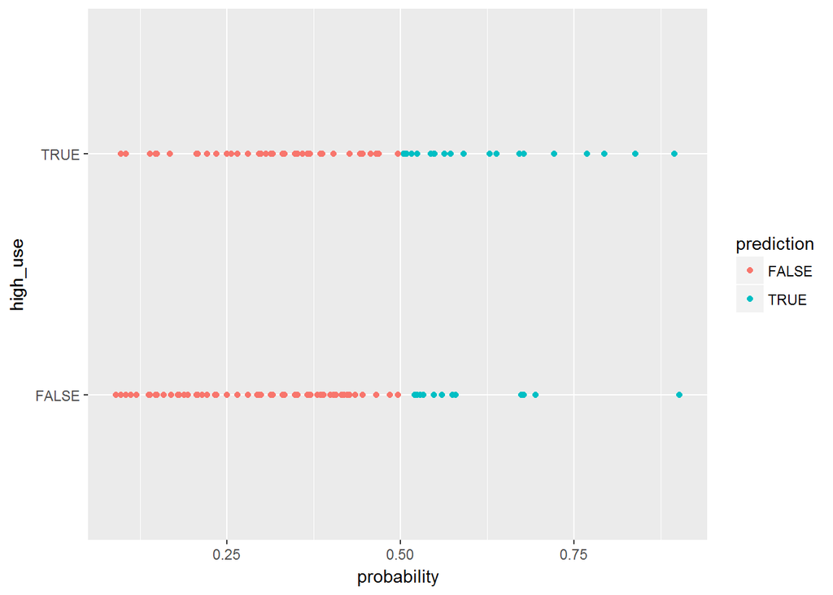

In the upper table and chart we can see the comparison of prediction of high use and current datas high use. The chart is pretty scattered and shows that this model is not the best one to be viewed with only two variables.

```
## [1] 0.2748691
```

In the above is the size of average false prediction in this model. This means that approximately 27% of the predictions this model makes are false. The performance of this model is not as good as expected in the beginning (hypothesis) and compared to simple guessing tactique this model is slightly more accurate.

```
## [1] 0.2853403
```

Last here is the 10-fold cross validation performed for this table. Unfortunately this model does not have smaller prediction error as in the DataCamp exercises ( approx. 0.26), but still is fairly close to it.